## Exercise 1

### Metropolis Algorithm

```r
# target distribution
pi_target <- function(theta) {
  return(theta / sum(1:6))
}

# Metropolis algorithm
metropolis_sampler <- function(S=10000, seed=1) {
  set.seed(1)
  states <- numeric(S)
  # Initialize state randomly
  states[1] <- sample(1:6, 1)
  for (s in 2:S) {
    current_state <- states[s-1]
    # Uniform proposal J(j|i) = 1/6
    proposed_state <- sample(1:6, 1)
    # acceptance probability
    alpha <- min(1, pi_target(proposed_state) / pi_target(current_state))
    # accept or reject proposal
    if (runif(1) < alpha) {
      states[s] <- proposed_state
    } else {
      states[s] <- current_state
    }
  }
  return(states)
}

samples <- metropolis_sampler(S=10000,seed=1)
```

### Why Symmetric

The proposal distribution is symmetric because the probability of moving from state i to state j is the same as moving from j to i. Mathematically $J(j \mid i)=J(i \mid j)=\frac{1}{6}$.

We need it to be symmetric because, we want the Markov chain to converge to the target distribution $\pi(\theta)$, which requires satisfying the detailed balance condition:

$$\pi(\theta)
P(\theta'\mid\theta)=\pi(\theta')P(\theta\mid\theta')$$

In the Metropolis Algorithm, the transition probability is given by:

$$P(\theta'\mid\theta)=J(\theta'\mid\theta) \cdot \min (1,
\frac{\pi(\theta')}{\pi(\theta)})$$

So if and only if $J(\theta'\mid\theta)=J(\theta\mid\theta')$, we have

$$\pi(\theta)
P(\theta'\mid\theta)=J(\theta'\mid\theta)\min({\pi(\theta),\pi(\theta')})=J(\theta'\mid\theta)\min({\pi(\theta),\pi(\theta')})=\pi(\theta')P(\theta\mid\theta')$$

(For the same reason, if we let the reject rate now to be $\frac{\pi(\theta')J(\theta\mid\theta')}{\pi(\theta)J(\theta'\mid\theta)}$, we the don’t need $J$ to be symmetric)

### Histogram and Comparison

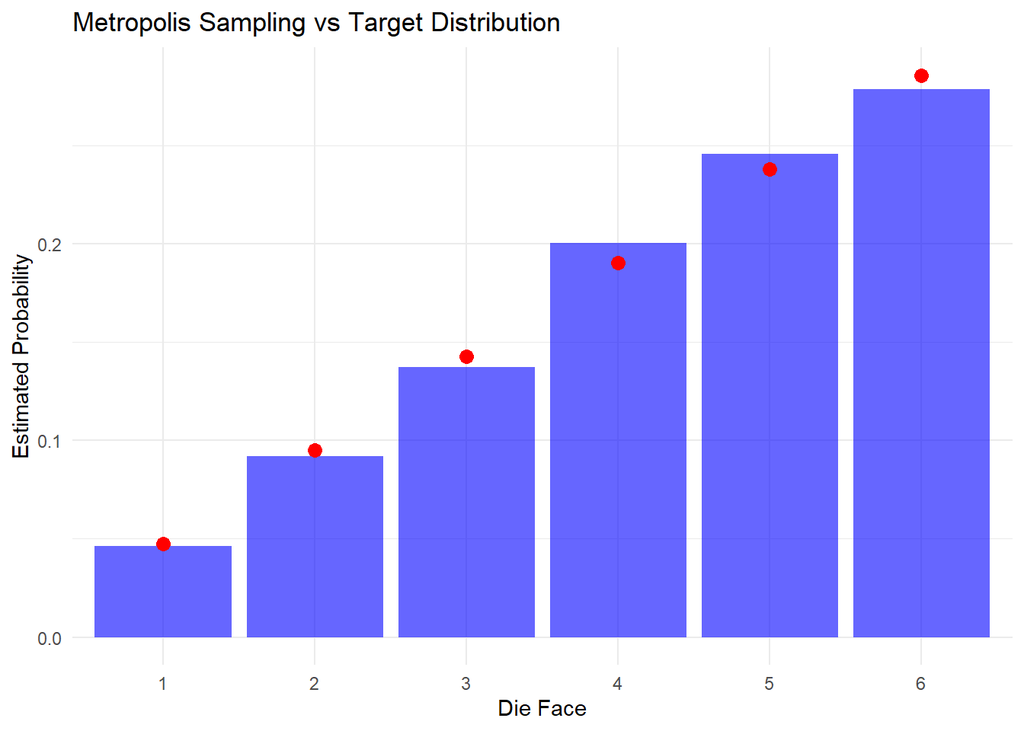

```r
suppressMessages(library(ggplot2))
data <- data.frame(Face = factor(samples, levels=1:6))
ggplot(data, aes(x=Face)) +
  geom_bar(aes(y = ..prop.., group = 1), fill="blue", alpha=0.6) +
  geom_point(data=data.frame(Face=factor(1:6), True_Prob=1:6 / sum(1:6)),
             aes(x=Face, y=True_Prob), color="red", size=3) +
  labs(title="Metropolis Sampling vs Target Distribution",
       x="Die Face", y="Estimated Probability") +
  theme_minimal()
```

This matches our intuition, the algorithm converges well.

## Exercise 2

### Metropolis-Hastings Algorithm

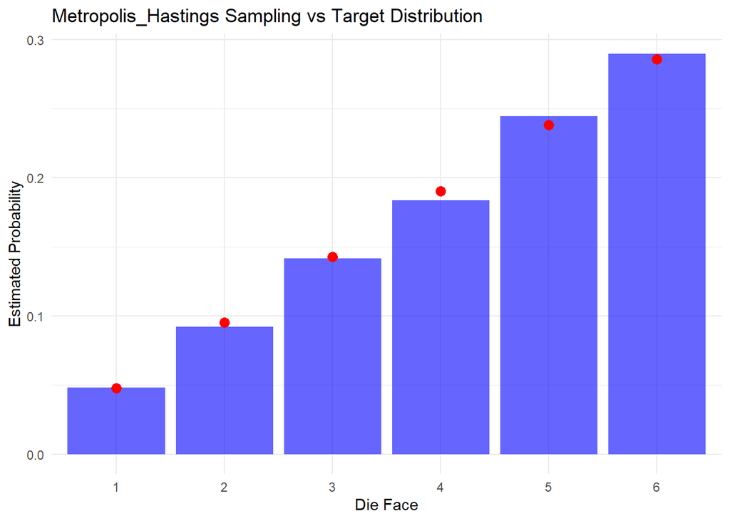

```r
# target distribution
pi_target <- function(theta) {
  return(theta / sum(1:6))
}
proposal_prob=c(0.05, 0.15, 0.2, 0.15, 0.15, 0.3)
proposal_distribution <- function() {
  return(sample(1:6, 1, prob=proposal_prob))
}

# Metropolis algorithm
metropolis_hastings_sampler <- function(S=10000, seed=1) {
  set.seed(1)
  states <- numeric(S)
  # Initialize state randomly
  states[1] <- sample(1:6, 1)
  for (s in 2:S) {
    current_state <- states[s-1]
    proposed_state <- proposal_distribution()
    # Compute proposal probability ratio
    r_ratio <- (pi_target(proposed_state) / pi_target(current_state)) *
               (proposal_prob[current_state] / proposal_prob[proposed_state])
    # Compute acceptance probability
    alpha <- min(1, r_ratio)
    # accept or reject proposal
    if (runif(1) < alpha) {
      states[s] <- proposed_state
    } else {
      states[s] <- current_state
    }
  }
  return(states)
}

samples_hastings <- metropolis_hastings_sampler(S=10000,seed=1)

data <- data.frame(Face = factor(samples_hastings, levels=1:6))
ggplot(data, aes(x=Face)) +
  geom_bar(aes(y = ..prop.., group = 1), fill="blue", alpha=0.6) +
  geom_point(data=data.frame(Face=factor(1:6), True_Prob=1:6 / sum(1:6)),
             aes(x=Face, y=True_Prob), color="red", size=3) +
  labs(title="Metropolis_Hastings Sampling vs Target Distribution",
       x="Die Face", y="Estimated Probability") +
  theme_minimal()
```

### ESS comparison

```r
library(coda)
ess_symmetric <- effectiveSize(samples)
ess_non_symmetric <- effectiveSize(samples_hastings)
print(paste("ESS for symmetric proposal:", ess_symmetric))
```

```
## [1] "ESS for symmetric proposal: 4619.50230168596"
```

```r
print(paste("ESS for non-symmetric proposal:", ess_non_symmetric))
```

```
## [1] "ESS for non-symmetric proposal: 7717.55468146539"
```

The non-symmetric proposal distribution (Metropolis-Hastings Algorithm) is preferable because it results in a higher Effective Sample Size (ESS), meaning the Markov chain produces more independent samples within the same number of iterations.

This is because the non-symmetric proposal here assigns higher probabilities to some states that are more likely under $\pi(\theta)$, like state 6; the chain has a higher chance of accepting proposals, making transitions smoother and reducing dependency between samples (the basic idea here is, if the proposal is rejected, then $\theta^{S+1}=\theta^S$ are dependent, reducing the ESS; if it is accepted, $\theta^{S+1}$ and $\theta^S$ will be independent).